# Homework on Jupyter

*Lets do some noise analysis with numpy and at the same time we learn some jupyter stuff too. We will try to find a periodic signal underlying an artificially created noisy time series data. We will use numpy and matplotlib.*

## Content

1. Introduction to Fourier Transform, but a short one
2. Signal processing

   a. Create a signal

   b. Add noise to the signal

   c. Inspect the spectral domain

   d. Remove some noise in the spectral domain

   e. Transform back the filtered spectrum to the time domain

## 1. Introduction to Fourier Transform, but a short one

The Fourier transform (FT) decomposes a function of time (a signal) into its constituent frequencies. This is similar to the way a musical chord can be expressed in terms of the volumes and frequencies of its constituent notes. The term Fourier transform refers to both the frequency domain representation and the mathematical operation that associates the frequency domain representation to a function of time. The Fourier transform of a function of time is itself a complex-valued function of frequency, whose magnitude (modulus) represents the amount of that frequency present in the original function, and whose argument is the phase offset of the basic sinusoid in that frequency. The Fourier transform is not limited to functions of time, but the domain of the original function is commonly referred to as the time domain. There is also an inverse Fourier transform that mathematically synthesizes the original function from its frequency domain representation.

The formula for Fourier transformation is the following:

\begin{equation} \hat{f}(\omega) = \int{f(t)\mathrm{e}^{-i\omega t}dt} \end{equation}

And the inverse Fourier transform has the following form:

\begin{equation} f(t) = \frac{1}{2\pi}\int{\hat{f}(\omega)\mathrm{e}^{i\omega t}d\omega} \end{equation}

Here is an example how does the a temporal signal and its corresponding fourier space image look like:

[figure not shown]

## 2. Signal processing

Now we turn our attention to the application of Fourier transform. We will create a theoretical signal that evolves in time, add some noise and try to retrieve the original signal from the noisy one using Fourier transforms.

### 2.a Create a signal

First we will import numpy and matplotlib packages.

```python
import numpy as np
import matplotlib.pyplot as plt
```

We define time window where we observe the signal, in this case from 0 to 15 seconds. We will observe 300 points in this interval. This means that our period is 15s. The signals form is saved into the `y_original` variable and its form is shown by the plot.

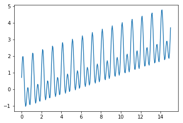

```python
N = 300
t = np.linspace(0,15, N)
T = t.max() - t.min()
y_original = np.sin(t*2*np.pi+np.pi/4) + np.sin(2*t*2*np.pi) + 0.2*t
plt.plot(t, y_original)
```

### 2.b Add noise to the signal

We take `y_original` and add normally distributed noise to it to obtained the signal that we would measure in real life. This is how we get `y_noisy`.

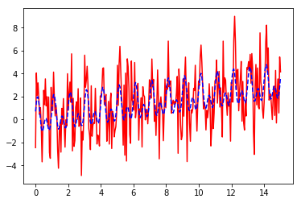

```python
y_noisy = y_original + 2*np.random.normal(size=len(y_original))
plt.plot(t, y_noisy, 'r')
plt.plot(t, y_original, '--b')
```

It is easy to see that the original signal is well hidden under the noise.

### 2.c Inspect the spectral domain

Now we turn to the Fourier domain and inspect the spectrum. First we calculate the step size in angular frequency, d$\omega$. The FFT procedure is an optimised algorithm therefore it puts the result into a specific format. In order to create frequencies in the same format we use the *np.fft.fftfreq* function and multiply it with the number of points *N* and the frequency step size to get the frequency scale right.

Finally we plot the spectrum and the spectral phase.

```
(-3, 3)
```

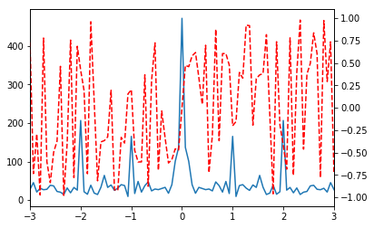

```python
dw = 2*np.pi / T
yft = np.fft.fft(y_noisy)
freq = np.fft.fftfreq(len(t))*N*dw

fig, ax1 = plt.subplots()

ax1.plot(np.fft.fftshift(freq)/2/np.pi, np.fft.fftshift(np.abs(yft)))

ax2 = ax1.twinx()
ax2.plot(np.fft.fftshift(freq)/2/np.pi, np.fft.fftshift(np.angle(yft))/np.pi, '--r')
plt.xlim([-3,3])
```

It is easy to see that there are basically two dominant spectral terms at frequency 1 and 2 as we would expect from the definition of `y_original` and a liner term at frequency 0. The phase appears to be quite noise.

### 2.d Remove some noise in the spectral domain

To reduce the noise we will set any spectral component to 0 that is smaller than 70 (this is a subjective rule, you could select other numbers).

```
(-3, 3)
```

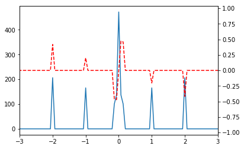

```python
yft_filtered = yft.copy()
yft_filtered[np.abs(yft_filtered) < 70] = 0

fig, ax1 = plt.subplots()

ax1.plot(np.fft.fftshift(freq)/2/np.pi, np.fft.fftshift(np.abs(yft_filtered)))

ax2 = ax1.twinx()
ax2.plot(np.fft.fftshift(freq)/2/np.pi, np.fft.fftshift(np.angle(yft_filtered))/np.pi, '--r')
plt.xlim([-3,3])
```

As you can see only the relevant spectral components have remained in the spectrum while the phase also became much smoother.

### 2.e Transform back the filtered spectrum to the time domain

Now we can turn it back to the temporal domain with the *np.fft.ifft* function and take the real values, since the original input was real valued.

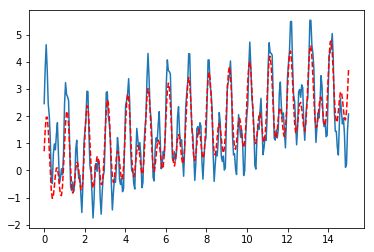

```python
y_filtered = np.real(np.fft.ifft(yft_filtered))

plt.plot(t, y_filtered)
plt.plot(t, y_original, '--r')
```

It is quite interesting to see how nicely we managed to reproduce the original signal with some differences.